# Homework 05 — K-Nearest Neighbors

Bias and variance, dimension, and handwritten digits

All numerical results were computed by running the Python code included in the appendix. The original assignment ZIP, data, source, and numerical outputs are preserved as local working materials. All KNN fits use equal neighbor weights, Euclidean distance unless stated otherwise, and no intercept column. NumPy’s `default_rng` supplies simulation randomness. The seed is set separately for each simulation setting.

## Question 1: Estimate the bias and variance of KNN

### (a) Target value and one training dataset

The true conditional mean is

$$f(\mathbf x_0)=0.5(0.5)+\sin(0.7)-0.3(1)^2
=0.5942176872.$$

Using seed **43251**, I generated 400 independent three-dimensional standard normal covariate vectors, with independent errors of standard deviation 0.1. For each odd $k$ from 1 through 29, the prediction is the average response of the $k$ nearest training observations. The single-dataset predictions are below.

| k | Prediction |
| --- | --- |
| 1 | 0.36960 |
| 3 | 0.43561 |
| 5 | 0.48207 |
| 7 | 0.45046 |
| 9 | 0.37116 |
| 11 | 0.34277 |
| 13 | 0.40834 |
| 15 | 0.38028 |
| 17 | 0.41486 |
| 19 | 0.38977 |
| 21 | 0.39950 |
| 23 | 0.35908 |
| 25 | 0.29767 |
| 27 | 0.33698 |
| 29 | 0.31805 |

### (b) Repeated sampling, decomposition, and interpretation

After the separate dataset in part (a), I generated **200 fresh independent training datasets** from the same random-number stream. Each repetition uses the same dataset for every $k$. The stored prediction array has shape $(200,15)$. Writing $\widehat f_{bk}$ for its entries, I computed

$$\widehat{\operatorname{Bias}}_k=\overline f_k-f(\mathbf x_0),\qquad
\widehat{\operatorname{Var}}_k=\frac1{200}\sum_{b=1}^{200}
(\widehat f_{bk}-\overline f_k)^2,$$
$$\widehat{\operatorname{MSE}}_k=\frac1{200}\sum_{b=1}^{200}
(\widehat f_{bk}-f(\mathbf x_0))^2.$$

| k | bias | squared_bias | variance | mse |
| --- | --- | --- | --- | --- |
| 1 | -0.02259 | 0.00051 | 0.04448 | 0.04499 |
| 3 | -0.03373 | 0.00114 | 0.01591 | 0.01705 |
| 5 | -0.03928 | 0.00154 | 0.01311 | 0.01466 |
| 7 | -0.04206 | 0.00177 | 0.01273 | 0.01450 |
| 9 | -0.06616 | 0.00438 | 0.01092 | 0.01530 |
| 11 | -0.06986 | 0.00488 | 0.01109 | 0.01597 |
| 13 | -0.07836 | 0.00614 | 0.01101 | 0.01715 |
| 15 | -0.08287 | 0.00687 | 0.00970 | 0.01657 |
| 17 | -0.08481 | 0.00719 | 0.00786 | 0.01505 |
| 19 | -0.09550 | 0.00912 | 0.00795 | 0.01707 |
| 21 | -0.10004 | 0.01001 | 0.00708 | 0.01709 |
| 23 | -0.10471 | 0.01096 | 0.00714 | 0.01811 |
| 25 | -0.10707 | 0.01146 | 0.00654 | 0.01801 |
| 27 | -0.11185 | 0.01251 | 0.00648 | 0.01899 |
| 29 | -0.11490 | 0.01320 | 0.00617 | 0.01937 |

The maximum absolute discrepancy in MSE = squared bias + variance is **$8.50\times10^{-17}$**, which is numerical roundoff. This is MSE for estimating the **mean response**. Predicting a fresh noisy response would add the independent noise variance $0.1^2=0.01$ to its expected error.

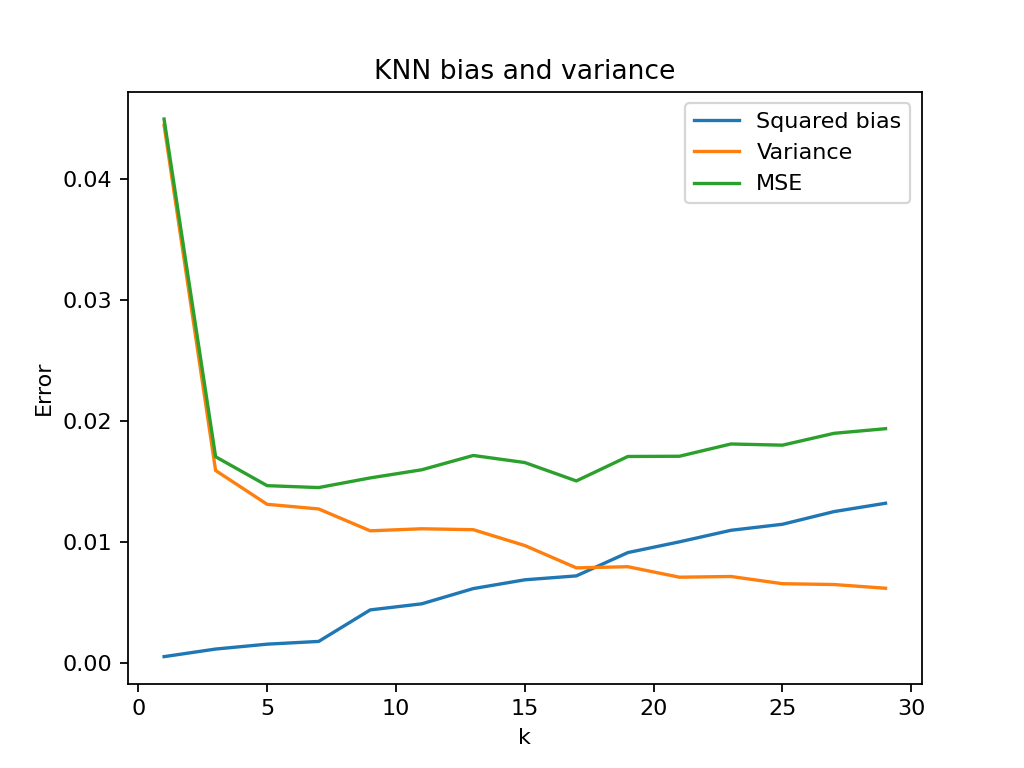

Squared bias, variance, and mean squared error over 200 datasets.

Variance falls sharply when moving from one neighbor to several neighbors, because averaging reduces sensitivity to individual responses and training locations. At larger $k$, neighborhoods extend farther from the target, so the fit averages observations with different conditional means. Here bias is negative throughout, and its squared magnitude increases. MSE is smallest among the tested values at **$k=7$ (0.01450)**, compared with 0.04499 at $k=1$ and 0.01937 at $k=29$. The empirical curves have small irregularities; monotonicity is not guaranteed by 200 repetitions.

Increasing $k$ smooths a KNN estimator, much as increasing the penalty reduces flexibility in ridge or lasso. Both can trade lower variance for greater bias. The mechanisms differ: KNN enlarges a local averaging neighborhood, ridge shrinks global linear slopes, and lasso can additionally set slopes to zero. The observed minimum is a simulation comparison at this target, not a universal choice of $k$.

## Question 2: Compare KNN with lasso

### (a) Fits and test results

I used seeds **43252** (independent covariates) and **43253** (correlation 0.8). Each setting contains 400 training and 1,000 independent test observations, shared by 5NN and lasso. The correlated covariates are generated as $X_j=\sqrt{0.8}U+\sqrt{0.2}V_j$, with independent standard normal $U,V_j$; this gives unit marginal variances and off-diagonal covariance 0.8.

5NN uses the generated covariate scale. For lasso, a `StandardScaler` and `Lasso` pipeline is refitted inside every training fold. `StandardScaler` uses the fold training means and standard deviations with divisor equal to the fold training size. Lasso fits an unpenalized intercept (equivalently centering the response). Its `alpha` is the $\lambda$ in the specified objective.

Ten-fold shuffled cross-validation uses the setting’s seed for fold assignment, mean validation squared error, and exactly `np.logspace(-4, 0, 41)` as the penalty grid. The selected pipeline is refitted on all training observations; test observations are transformed using those fitted training statistics. No test observations are used to choose the penalty. Slopes with absolute standardized coefficient greater than $10^{-8}$ count as nonzero. All fits completed without convergence warnings at tolerance $10^{-10}$ and maximum 100,000 iterations.

| setting | seed | 5NN test MSE | Lasso test MSE | Selected penalty | Nonzero slopes |
| --- | --- | --- | --- | --- | --- |
| 1 | 43252 | 0.561643 | 0.240845 | 0.019953 | 20 |
| 2 | 43253 | 0.179490 | 0.253666 | 0.015849 | 5 |

### (b) Correlation and neighborhoods

In Setting 1, lasso’s test MSE (0.24084) is lower than 5NN’s (0.56164). Euclidean distance uses all 30 coordinates, including the 27 coordinates absent from the response equation. Two observations close in the three relevant coordinates can be far apart in the remaining coordinates. Lasso can downweight or omit covariates; it does not give every coordinate an equal role in prediction. Nevertheless, the selected fit retains 20 slopes, illustrating that predictive cross-validation is not a guarantee of recovering the true variable set.

In Setting 2, 5NN’s MSE falls to 0.17949 and is lower than lasso’s 0.25367. The common component makes distance convey information about a shared direction that also affects the relevant covariates. Correlated coordinates can therefore make a neighborhood more informative than unrelated noise coordinates. This design still has variation in every direction: the covariance eigenvalues are 24.2 along the common direction and 0.2 in each of the other 29 directions. It is not exactly one-dimensional. Lasso retains five slopes and can use a small set of correlated variables as substitutes, while KNN measures distance using all 30.

### (c) Nonlinearity and the scope of the comparison

The lasso predictor is linear, but the conditional mean contains both a sine and a square. A linear coefficient for $X_2$ can approximate part of the sine relationship but cannot reproduce it, and a linear term in $X_3$ cannot represent the even quadratic effect. The intercept can absorb an average quadratic contribution, not its observation-specific variation. KNN can adapt to nonlinear structure when useful neighbors are available, but it can suffer large finite-sample error in a high-dimensional distance space.

Thus the comparison combines sparsity, correlation, nonlinear approximation, and finite-sample neighborhood quality. It does not establish that correlation always helps KNN or that either method is always better. There is only one training/test realization per setting, and different response functions, sample sizes, correlations, or values of $k$ can change the result.

## Question 3: Observed dimension and latent dimension

### (a) Single experiments and (b) 50 repetitions

Seeds are **43254** for $m=3$ and **43255** for $m=30$. In each setting I first generated a single experiment, then 50 fresh complete experiments. Each experiment has a new $100\times m$ loading matrix with independent Uniform$[-2,2]$ entries, shared across its 200 training and 200 test observations. All latent variables, measurement errors, and response errors are independent standard normals as specified. KNN sees only the 100 observed coordinates on their generated scale. Within an experiment all values of $k$ use the same training and test data.

The table reports each single experiment and the averages of the 50 additional experiments. Monte Carlo standard errors quantify variability of those averages.

| k | single_mse, m=3 | single_mse, m=30 | average_mse, m=3 | average_mse, m=30 | monte_carlo_se, m=3 | monte_carlo_se, m=30 |
| --- | --- | --- | --- | --- | --- | --- |
| 2 | 1.71623 | 3.08584 | 1.66820 | 3.05472 | 0.02341 | 0.04332 |
| 10 | 1.33468 | 2.55183 | 1.30392 | 2.36680 | 0.01894 | 0.02567 |
| 18 | 1.35934 | 2.53594 | 1.31196 | 2.34645 | 0.01937 | 0.02611 |
| 26 | 1.43735 | 2.56803 | 1.35994 | 2.36992 | 0.02190 | 0.02746 |
| 34 | 1.49495 | 2.54787 | 1.41379 | 2.40855 | 0.02303 | 0.02860 |
| 42 | 1.55652 | 2.60109 | 1.46747 | 2.43930 | 0.02468 | 0.02966 |
| 50 | 1.61275 | 2.61628 | 1.52626 | 2.47009 | 0.02590 | 0.03051 |
| 58 | 1.65928 | 2.59860 | 1.58461 | 2.50368 | 0.02731 | 0.03141 |
| 66 | 1.72367 | 2.63395 | 1.64163 | 2.53154 | 0.02857 | 0.03202 |
| 74 | 1.76695 | 2.66031 | 1.70178 | 2.56312 | 0.02973 | 0.03264 |
| 82 | 1.82602 | 2.68394 | 1.76136 | 2.59356 | 0.03035 | 0.03347 |

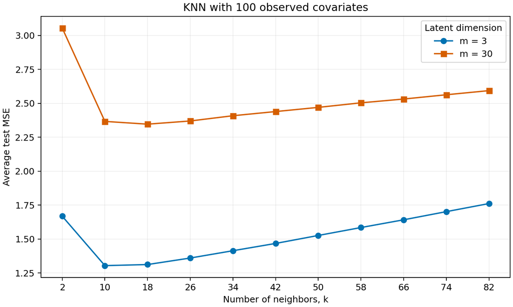

Average test MSE across 50 independent complete experiments for each latent dimension.

The $m=3$ setting performs better at every tested $k$. Its lowest average MSE is **1.30392 at $k=10$**, while for $m=30$ the lowest average is **2.34645 at $k=18$**. These are descriptive minima over the specified grid; the test curves are not a cross-validation procedure for tuning a final model.

### (c) Why latent dimension matters

For $m=3$, observed proximity can carry substantial information about just three latent coordinates, two of which determine the conditional response. For $m=30$, distances also respond to 28 latent coordinates absent from the response equation. With only 200 training points, close neighbors in that larger latent space are much harder to find. The same observed dimension $p=100$ and the same number of response-relevant latent variables therefore do not imply comparable KNN performance. The loading geometry and signal magnitude also change under this specified design, so the experiment is not a pure dimension-only intervention.

For a fixed loading matrix, $\operatorname{Cov}(\mathbf X\mid\mathbf A) =\mathbf A\mathbf A^{\mathsf T}+\mathbf I_{100}$ is full rank. Without $\boldsymbol\eta$, observations lie in the column space of $\mathbf A$, of dimension at most $m$. Adding independent measurement noise gives variation in directions orthogonal to that space, blurs latent proximity, and prevents the observed data from lying exactly on an $m$-dimensional linear subspace. For two independent observations, the expected squared distance contributed by measurement noise alone is $2p=200$. Response noise has variance one, providing an irreducible contribution to test MSE even with perfectly observed latent signals; imperfect recovery from $\mathbf X$ can add further error.

## Question 4: Classify handwritten digits

### (a) Direct implementation

I used the first 1,000 training and 500 test rows from the course’s compressed CSV copies, preserving their order. The first column supplies labels only; distances use the 256 original pixel intensities without standardization. The implementation computes distances directly, sorts stably so equal distances favor the smaller training row number, and uses the first maximum of the digit counts so voting ties favor the smallest digit. No built-in distance or KNN function is used for this question.

```python
def classify_5nn(x_train,y_train,x_test,metric):
    if metric not in ('euclidean','manhattan'): raise ValueError('Unknown distance')
    predictions=[]
    for point in x_test:
        diff=x_train-point
        distance=np.sqrt(np.sum(diff**2,axis=1)) if metric=='euclidean' else np.sum(abs(diff),axis=1)
        # Stable sorting retains ascending training-row order for equal distances.
        nearest=np.argsort(distance,kind='stable')[:5]
        predictions.append(np.bincount(y_train[nearest],minlength=10).argmax())
    return np.array(predictions)
```

### (b) Errors and confusion matrices

| Distance | Errors / 500 | Error rate |
| --- | --- | --- |
| Euclidean | 61 / 500 | 0.122 |
| Manhattan | 69 / 500 | 0.138 |

**Euclidean distance.** Rows are predicted digits; columns are true digits.

| Predicted / True | 0 | 1 | 2 | 3 | 4 | 5 | 6 | 7 | 8 | 9 |
| --- | --- | --- | --- | --- | --- | --- | --- | --- | --- | --- |
| 0 | 118 | 0 | 7 | 1 | 0 | 4 | 2 | 0 | 2 | 0 |
| 1 | 0 | 66 | 0 | 0 | 2 | 0 | 0 | 0 | 0 | 1 |
| 2 | 0 | 0 | 39 | 1 | 0 | 0 | 2 | 0 | 0 | 1 |
| 3 | 0 | 0 | 0 | 23 | 0 | 4 | 0 | 0 | 2 | 0 |
| 4 | 0 | 0 | 1 | 0 | 27 | 1 | 1 | 1 | 0 | 1 |
| 5 | 0 | 0 | 0 | 1 | 0 | 13 | 0 | 0 | 0 | 0 |
| 6 | 0 | 2 | 0 | 0 | 0 | 1 | 41 | 0 | 2 | 0 |
| 7 | 0 | 0 | 0 | 0 | 1 | 1 | 0 | 34 | 0 | 4 |
| 8 | 0 | 0 | 3 | 2 | 0 | 2 | 0 | 0 | 37 | 0 |
| 9 | 1 | 0 | 0 | 1 | 4 | 0 | 0 | 1 | 1 | 41 |

The largest combined two-direction confusion counts are **0 and 2 (7)**, **7 and 9 (5)**, **4 and 9 (5)**, **3 and 5 (5)**.

**Manhattan distance.** Rows are predicted digits; columns are true digits.

| Predicted / True | 0 | 1 | 2 | 3 | 4 | 5 | 6 | 7 | 8 | 9 |
| --- | --- | --- | --- | --- | --- | --- | --- | --- | --- | --- |
| 0 | 118 | 0 | 6 | 1 | 0 | 5 | 3 | 0 | 4 | 0 |
| 1 | 0 | 67 | 2 | 0 | 2 | 0 | 1 | 0 | 0 | 1 |
| 2 | 0 | 0 | 35 | 0 | 0 | 0 | 2 | 0 | 0 | 0 |
| 3 | 0 | 0 | 1 | 24 | 0 | 4 | 0 | 0 | 2 | 0 |
| 4 | 0 | 0 | 1 | 1 | 27 | 1 | 0 | 1 | 0 | 1 |
| 5 | 0 | 0 | 0 | 1 | 0 | 11 | 0 | 0 | 0 | 0 |
| 6 | 0 | 1 | 0 | 0 | 0 | 2 | 40 | 0 | 2 | 0 |
| 7 | 0 | 0 | 2 | 1 | 1 | 0 | 0 | 34 | 0 | 5 |
| 8 | 0 | 0 | 2 | 0 | 0 | 3 | 0 | 0 | 34 | 0 |
| 9 | 1 | 0 | 1 | 1 | 4 | 0 | 0 | 1 | 2 | 41 |

The largest combined two-direction confusion counts are **7 and 9 (6)**, **0 and 2 (6)**, **4 and 9 (5)**, **3 and 5 (5)**, **0 and 5 (5)**.

Each matrix retains all ten labels and sums to 500. The off-diagonal totals are 61 and 69, respectively. Pair counts above combine both directions and are raw counts, so they also reflect class frequencies.

### (c) Misclassified images and distance comparison

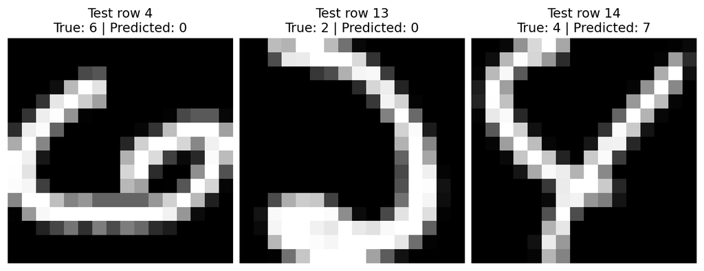

Three Euclidean 5NN mistakes, with one-based test row numbers and true/predicted labels.

The 6 in row 4 has a strong lower loop and a broad rounded outline, helping explain its confusion with 0. The 2 in row 13 has a long rounded right edge and a heavy bottom stroke; the 0 prediction is understandable from coarse pixel similarity, although its upper stroke still suggests a 2. The open 4 in row 14 has an oblique right stroke and a weak crossbar, which can resemble a slanted 7. These are visual interpretations of low-resolution shapes rather than evidence that the assigned labels are wrong.

Euclidean distance makes eight fewer errors (1.6 percentage points) on these 500 images. Manhattan distance sums absolute coordinate differences, whereas Euclidean distance puts relatively more emphasis on large coordinate differences through squaring. Their neighbor sets need not match.

The two classifiers predict different labels on **22 images**. They are both wrong on **58**, only Euclidean is wrong on **3**, and only Manhattan is wrong on **11**. Thus 428 images are correctly classified by both. Among the 58 shared mistakes, eight have different wrong predicted labels. Similar overall error rates can therefore conceal different individual mistakes. The observed advantage on this test subset does not establish that one metric is universally better.

## Question 5: Create a plot-formatting skill

### (a) Scope and formatting choices

I created `stat432-homework-plots` as a short, portable skill for R and Python STAT 432 homework plots. It requires an explicit request and addresses margins, titles, axis labels, colors, line distinctions, and figure/text sizes. The instructions preserve the calculations and keep both original and revised figures. The installed invocation policy also disables implicit invocation.

### (b) Installation, invocation, and comparison

I installed the skill in the local Codex skills directory, validated it, and invoked it with **“Install and use $stat432-homework-plots.”** I applied its formatting rules to the Question 1 plot. Both versions below use identical numerical results.

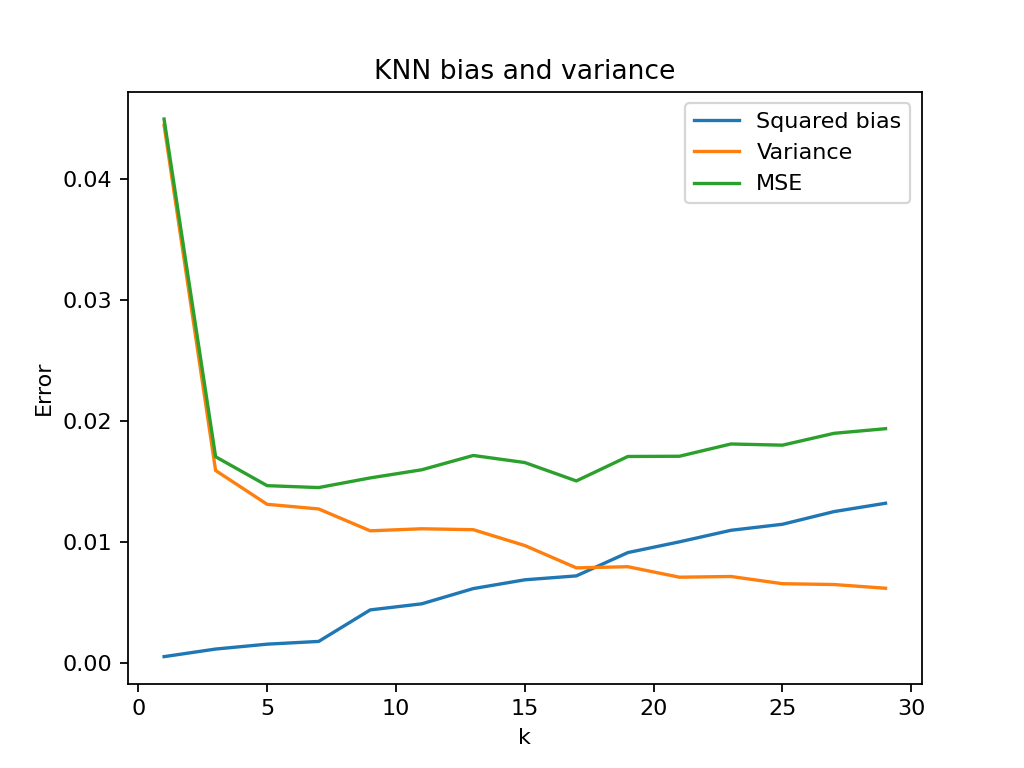

Original plot: default styling and generic axis text.

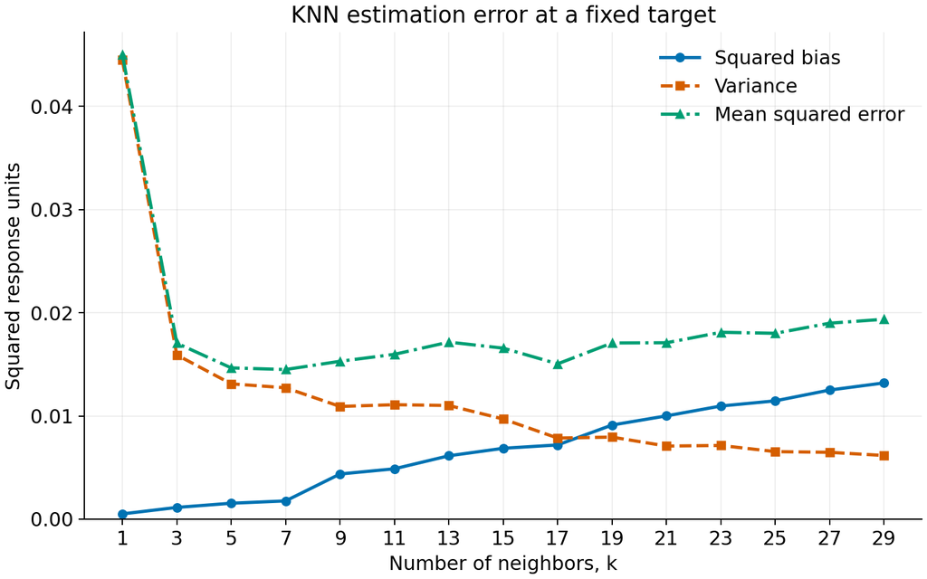

Revised plot: more descriptive labels, distinct markers and line styles, a light grid, and ticks at the tested k values.

I kept the original plot in Question 1 because its simpler styling is easier to read. The revised version adds explicit labels, markers, and gridlines, but the extra detail makes the figure feel busier. Both versions are shown here for comparison, and the skill remains installed for future use.

### (c) Final skill and experience

The revision makes the curves distinguishable without relying solely on color, shows the exact tested neighbor counts, and explains the vertical units. A single revision was tested and the exported plot was checked for clipped text and overlap. More formatting is not automatically better: in this case, I found the simpler original clearer. The comparison required no changes to the simulation or numerical estimates. The final skill content is reproduced verbatim below.

```markdown
---
name: stat432-homework-plots
description: Improve formatting of STAT 432 homework plots in R or Python only when the user explicitly requests this skill. Do not invoke for other plots or analysis changes.
---

# STAT 432 Homework Plot Formatting

- Preserve data, estimates, and conclusions; change only presentation. Save a revised figure alongside the original for comparison.
- Use a roughly 8 by 5 inch figure, readable 11–13 point text, and 180 dpi or higher for raster output. Adjust sizes for multiple panels.
- Give titles a short statistical meaning. Label both axes with the quantity and units, and spell out abbreviations in labels or legends.
- Use sufficient margins so titles, ticks, and legends are not clipped. In Python prefer constrained layout; in R adjust plot margins or ggplot theme spacing.
- Use a colorblind-friendly palette such as blue, orange, and green, with different markers or line styles so color is not the sole distinction.
- Use light major gridlines and an uncluttered background. Include zero for nonnegative error curves unless doing so hides a meaningful comparison; explain any truncated scale.
- Match tick spacing to the measured values and keep labels readable. Place legends away from the data; use shared scales for comparable panels.
- Inspect the exported figure at its report size and compare it with the original before keeping the revision.
```

## Appendix: Reproducible analysis

Run `python analysis-05.py`, then `python style-plots-05.py`, from the working folder. Dependencies are NumPy, pandas, Matplotlib, scikit-learn, and threadpoolctl. The original ZIP supplies the data files.

```python
from pathlib import Path
import json, warnings
import numpy as np
import pandas as pd
import matplotlib
matplotlib.use('Agg')
import matplotlib.pyplot as plt
from sklearn.pipeline import Pipeline
from sklearn.preprocessing import StandardScaler
from sklearn.linear_model import Lasso
from sklearn.model_selection import GridSearchCV, KFold
from sklearn.neighbors import KNeighborsRegressor
from sklearn.exceptions import ConvergenceWarning
from threadpoolctl import threadpool_limits

ROOT = Path(__file__).resolve().parent
OUT = ROOT / 'results'
OUT.mkdir(exist_ok=True)
threadpool_limits(2)
warnings.filterwarnings('error', category=ConvergenceWarning)
def f(x): return .5*x[:, 0] + np.sin(x[:, 1]) - .3*x[:, 2]**2
def save(df, name): df.to_csv(OUT / (name+'.csv'), index=False)

# Question 1: a separate single dataset, then 200 fresh datasets.
rng = np.random.default_rng(43251)
ks = np.arange(1, 30, 2)
x0 = np.array([.5,.7,1.])
truth = f(x0[None,:])[0]
def q1_draw():
    x = rng.normal(size=(400,3)); y = f(x)+rng.normal(0,.1,400)
    order = np.argsort(np.sum((x-x0)**2,axis=1),kind='stable')
    return np.cumsum(y[order])[ks-1]/ks
single = q1_draw()
pred = np.array([q1_draw() for _ in range(200)])
np.save(OUT/'q1-predictions.npy',pred)
bias = pred.mean(0)-truth; var = pred.var(0,ddof=0)
mse = ((pred-truth)**2).mean(0)
assert np.allclose(mse,bias**2+var,rtol=1e-12,atol=1e-14)
save(pd.DataFrame(dict(k=ks,single_prediction=single,bias=bias,squared_bias=bias**2,variance=var,mse=mse)), 'q1')
fig,ax=plt.subplots()
for y,label in [(bias**2,'Squared bias'),(var,'Variance'),(mse,'MSE')]: ax.plot(ks,y,label=label)
ax.set(xlabel='k',ylabel='Error',title='KNN bias and variance'); ax.legend()
fig.savefig(OUT/'q1-original.png',dpi=160); plt.close(fig)
print('Q1', truth, 'identity discrepancy',np.max(abs(mse-bias**2-var)),flush=True)

# Question 2: all preprocessing is inside CV; no test-set tuning.
rows=[]
for setting,seed,rho in [(1,43252,0.),(2,43253,.8)]:
    rng=np.random.default_rng(seed)
    def draw(n):
        if rho:
            x=np.sqrt(rho)*rng.normal(size=(n,1))+np.sqrt(1-rho)*rng.normal(size=(n,30))
        else: x=rng.normal(size=(n,30))
        return x,f(x)+rng.normal(0,.1,n)
    x,y=draw(400); xt,yt=draw(1000)
    knn=KNeighborsRegressor(n_neighbors=5,weights='uniform',metric='euclidean').fit(x,y)
    pipe=Pipeline([('scale',StandardScaler()),('lasso',Lasso(tol=1e-10,max_iter=100000))])
    cv=GridSearchCV(pipe,{'lasso__alpha':np.logspace(-4,0,41)},
        scoring='neg_mean_squared_error',cv=KFold(10,shuffle=True,random_state=seed),n_jobs=1)
    cv.fit(x,y)
    coef=cv.best_estimator_.named_steps['lasso'].coef_
    rows.append(dict(setting=setting,seed=seed,knn_mse=np.mean((knn.predict(xt)-yt)**2),
        lasso_mse=np.mean((cv.predict(xt)-yt)**2),penalty=cv.best_params_['lasso__alpha'],nonzero=np.sum(abs(coef)>1e-8)))
    save(pd.DataFrame({'penalty':cv.cv_results_['param_lasso__alpha'],'cv_mse':-cv.cv_results_['mean_test_score']}),f'q2-cv-{setting}')
save(pd.DataFrame(rows),'q2'); print('Q2',rows,flush=True)

# Question 3: generate a new loading matrix for every complete experiment.
ks3=np.arange(2,83,8); q3=[]
for m,seed in [(3,43254),(30,43255)]:
    rng=np.random.default_rng(seed)
    def experiment():
        a=rng.uniform(-2,2,(100,m))
        def draw():
            z=rng.normal(size=(200,m))
            x=z@a.T+rng.normal(size=(200,100))
            y=z[:,0]+z[:,1]+rng.normal(size=200)
            return x,y
        x,y=draw(); xt,yt=draw()
        model=KNeighborsRegressor(n_neighbors=82,weights='uniform',metric='euclidean').fit(x,y)
        idx=model.kneighbors(xt,return_distance=False)
        yp=np.cumsum(y[idx],axis=1)[:,ks3-1]/ks3
        return ((yp-yt[:,None])**2).mean(0)
    single=experiment(); repeated=np.array([experiment() for _ in range(50)])
    np.save(OUT/f'q3-m{m}-mse.npy',repeated)
    for k,s,avg,se in zip(ks3,single,repeated.mean(0),repeated.std(0,ddof=1)/np.sqrt(50)):
        q3.append(dict(m=m,k=k,single_mse=s,average_mse=avg,monte_carlo_se=se))
save(pd.DataFrame(q3),'q3')
fig,ax=plt.subplots(figsize=(8,4.8),layout='constrained')
for m,c,mark in [(3,'#0072B2','o'),(30,'#D55E00','s')]:
    d=pd.DataFrame(q3).query('m == @m')
    ax.plot(d.k,d.average_mse,color=c,marker=mark,label=f'm = {m}')
ax.set(xlabel='Number of neighbors, k',ylabel='Average test MSE',title='KNN with 100 observed covariates',xticks=ks3)
ax.legend(title='Latent dimension'); ax.grid(alpha=.2)
fig.savefig(OUT/'q3.png',dpi=180); plt.close(fig)
print('Q3 complete',flush=True)

# Question 4: direct distances and deterministic ties, without distance/KNN APIs.
train=pd.read_csv(ROOT/'data/knn/zip-train.csv.gz',header=None).to_numpy()[:1000]
test=pd.read_csv(ROOT/'data/knn/zip-test.csv.gz',header=None).to_numpy()[:500]
x=train[:,1:]; labels=train[:,0].astype(int); xt=test[:,1:]; truth4=test[:,0].astype(int)
def classify_5nn(x_train,y_train,x_test,metric):
    if metric not in ('euclidean','manhattan'): raise ValueError('Unknown distance')
    predictions=[]
    for point in x_test:
        diff=x_train-point
        distance=np.sqrt(np.sum(diff**2,axis=1)) if metric=='euclidean' else np.sum(abs(diff),axis=1)
        # Stable sorting retains ascending training-row order for equal distances.
        nearest=np.argsort(distance,kind='stable')[:5]
        predictions.append(np.bincount(y_train[nearest],minlength=10).argmax())
    return np.array(predictions)
preds={}
for metric in ['euclidean','manhattan']:
    yp=classify_5nn(x,labels,xt,metric); preds[metric]=yp
    cm=np.zeros((10,10),dtype=int); np.add.at(cm,(yp,truth4),1)
    assert cm.sum()==500
    pd.DataFrame(cm,index=range(10),columns=range(10)).to_csv(OUT/f'q4-{metric}-confusion.csv')
    print('Q4',metric,'error',np.mean(yp!=truth4),flush=True)
save(pd.DataFrame({'true':truth4,**preds}),'q4-predictions')
wrong=np.flatnonzero(preds['euclidean']!=truth4)[:3]
fig,axes=plt.subplots(1,3,figsize=(9,3.8),layout='constrained')
for ax,i in zip(axes,wrong):
    ax.imshow(xt[i].reshape(16,16),cmap='gray',vmin=-1,vmax=1)
    ax.set_title(f'Test row {i+1}\nTrue: {truth4[i]} | Predicted: {preds["euclidean"][i]}')
    ax.axis('off')
fig.savefig(OUT/'q4-errors.png',dpi=180,bbox_inches='tight'); plt.close(fig)
summary={'q1_truth':truth,'q1_identity_error':float(np.max(abs(mse-bias**2-var))),
    'q4_examples':(wrong+1).tolist(),'q4_prediction_disagreements':int(np.sum(preds['euclidean']!=preds['manhattan'])),
    'q4_both_wrong':int(np.sum((preds['euclidean']!=truth4)&(preds['manhattan']!=truth4))),
    'q4_euclidean_only_wrong':int(np.sum((preds['euclidean']!=truth4)&(preds['manhattan']==truth4))),
    'q4_manhattan_only_wrong':int(np.sum((preds['euclidean']==truth4)&(preds['manhattan']!=truth4)))}
(OUT/'summary.json').write_text(json.dumps(summary,indent=2))
print(summary,flush=True)
```

### Formatting revision code

```python
from pathlib import Path
import pandas as pd
import matplotlib
matplotlib.use('Agg')
import matplotlib.pyplot as plt

root=Path(__file__).resolve().parent
d=pd.read_csv(root/'results/q1.csv')
with plt.rc_context({'font.size':12,'axes.titlesize':14,'axes.labelsize':12}):
    fig,ax=plt.subplots(figsize=(8,5),layout='constrained')
    for col,label,color,marker,style in [
        ('squared_bias','Squared bias','#0072B2','o','-'),
        ('variance','Variance','#D55E00','s','--'),
        ('mse','Mean squared error','#009E73','^','-.')]:
        ax.plot(d.k,d[col],label=label,color=color,marker=marker,linestyle=style,linewidth=2,markersize=5)
    ax.set(title='KNN estimation error at a fixed target',xlabel='Number of neighbors, k',
        ylabel='Squared response units',xticks=d.k,ylim=(0,None))
    ax.grid(alpha=.2); ax.spines[['top','right']].set_visible(False)
    ax.legend(frameon=False,loc='upper right')
    fig.savefig(root/'results/q1-revised.png',dpi=180)
```